# act_report slides

**Analyze and Visualize**

**By Mohammed Alsenani**

In this report I will show you some visualizations and some insights about @dog_rates twitter account which is account for rating a dogs. you will see

- The relationship between favorites and retweets count
- The most owned dog from the account
- The most gender rated on the account

> Favorites (likes) and retweets is an index to know if the tweet get popular or not. There is no direct communicate between them but I try to get a connection. I see that the favorites on the account is about retweets four times.
> - Most retweeted tweet get about 80,000 retweet (which is not easy number)
> - Most favorited tweet get abot 150,000 favorite (also huge number)

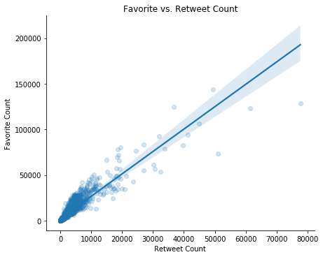

```python
# Plot scatterplot of retweet vs favorite count
sns.lmplot(x="retweets",
           y="favorites",
           data=df,
           size = 5,
           aspect=1.3,
           scatter_kws={'alpha':1/5})
plt.title('Favorite vs. Retweet Count')
plt.xlabel('Retweet Count')
plt.ylabel('Favorite Count');
```

> In this account I found four stages of dogs Pupper, floofer, puppo and doggo and from these stages I get some analysis that says
> - The most stage came in the account is Pupper
> - The second is doggo
> - The third is puppo
> - The fourth and last is floofer

> But for the average rating we have another order which is
> - The highest average rating is puppo with average equal to 12.04
> - The second is doggo with average equal to 11.88
> - The third is floofer with average equal to 11.87
> - The fourth and last is pupper with average equal to 10.63 The average rating maybe not correct 100% because the count of the three stages collceted together is about 30% of pupper stage

```
(-1.288268191449591,
 1.2310305760057396,
 -1.2401381220397572,
 1.2110819987279693)
```

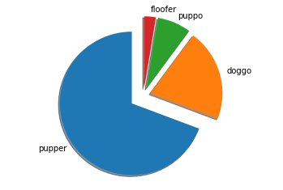

```python
# Plot the data partitioned by dog stage
dog_stage_count = list(df[df['dog_stage'] != 'None']['dog_stage'].value_counts())[0:4]
dog_stages = df[df['dog_stage'] != 'None']['dog_stage'].value_counts().index.tolist()[0:4]
explode = (0.2, 0.1, 0.1, 0.1)

fig1, ax1 = plt.subplots()
ax1.pie(dog_stage_count, explode = explode, labels = dog_stages, shadow = True, startangle = 90)
ax1.axis('equal')
```

```python
df[df['dog_stage'] != 'None'].groupby('dog_stage')['rating_numerator'].mean()
```

```
dog_stage
doggo      11.888889
floofer    11.875000
pupper     10.638066
puppo      12.043478
Name: rating_numerator, dtype: float64
```

> The gender is one of the choosing criteria some people choose female and others choose male but if we have a data we must take a look!

> Our data says that
> - Male dogs is the most rated
> - Male dogs is about 2.5 times of female

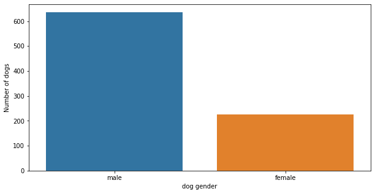

```python
# bar chart
plt.figure(figsize = [10, 5])

graph = sns.countplot(data = df, x = "dog_gender", order = df.dog_gender.value_counts().index);
graph.set_xlabel('dog gender');
graph.set_ylabel('Number of dogs');
```